# *Explanatory Data Analysis: Customer and Sales Insights for a UK-Based Online Gift Retailer*

*Dataset Source: https://www.kaggle.com/datasets/vijayuv/onlineretail?select=OnlineRetail.csv*

## 1. Introduction and Business Context

### 1.1 Role and Objective

This project adopts the role of a data science consultant. Our client is a UK-based purely online retailer having no presence of brick and mortar stores. Gift items are their main offerings that are entirely sold via their website. The biggest part of the clients consists of small wholesalers who do bulk orders and not small consumers who buy single items. The key task was building an EDA pipeline via Jupyter Notebook, identifying the real business factors out of transaction history data, and delivering it in such a managerially useful way that could be adopted at the executive level. The pipeline includes the processing from original files through the loading to the stage of explanatory graphs, while the reasoning for any analytical step is explained.

### 1.2 Who the Analysis Is For

The intended audience consists of the Sales and Marketing directors. They are not data scientists. The analysis focuses on four key business questions. First, the analysis examines which customers contribute most to revenue and the extent of customer concentration. Second, when exactly does demand go up and down across the year and across the week, because getting that wrong means either overstocking or running out at the worst time. Third, which countries outside the UK are actually worth spending marketing money on versus which ones just generate noise. Fourth, the analysis examines whether frequently co-purchased products could provide opportunities for bundling and cross-selling. Each chart is designed to address one of these four business questions directly, following the principle that a good visualisation should make the viewer think about the data rather than the design.

# Import python library

```python
import pandas as pd
import numpy as np
import matplotlib.pyplot as plt
from itertools import combinations
from collections import Counter
```

### 1.3 About the Dataset

The analysis uses the UCI Online Retail dataset, originally donated to the UCI Machine Learning Repository and available on Kaggle at the URL listed on the title page. It has 541,909 rows covering transactions from 1 December 2010 to 9 December 2011. Each row is one product line on one invoice, with eight columns: InvoiceNo, StockCode, Description, Quantity, InvoiceDate, UnitPrice, CustomerID, and Country. The dataset was selected for three main reasons. The dataset was not used in the module exercises and therefore meets the brief's requirement for a new dataset. It is large enough and messy enough to require real cleaning decisions, not just a quick dropna call. And its structure supports several genuinely different analytical angles, from customer segmentation to seasonal patterns to market-level comparisons.

# Load Dataset

```python
plt.rcParams['figure.dpi'] = 100
pd.set_option('display.width', 100)

def load_data(path='OnlineRetail.csv'):
    for enc in ['utf-8', 'cp1252', 'latin1']:
        try:
            return pd.read_csv(path, parse_dates=['InvoiceDate'], encoding=enc)
        except UnicodeDecodeError:
            continue
    raise ValueError('Could not decode file with utf-8, cp1252, or latin1 encoding')

df = load_data()
print(df.shape)
df.head(3)
```

```
(541909, 8)
```

|  | InvoiceNo | StockCode | Description | Quantity | InvoiceDate | UnitPrice | CustomerID | Country |
| --- | --- | --- | --- | --- | --- | --- | --- | --- |
| 0 | 536365 | 85123A | WHITE HANGING HEART T-LIGHT HOLDER | 6 | 2010-12-01 08:26:00 | 2.55 | 17850.0 | United Kingdom |
| 1 | 536365 | 71053 | WHITE METAL LANTERN | 6 | 2010-12-01 08:26:00 | 3.39 | 17850.0 | United Kingdom |
| 2 | 536365 | 84406B | CREAM CUPID HEARTS COAT HANGER | 8 | 2010-12-01 08:26:00 | 2.75 | 17850.0 | United Kingdom |

## 2. Data Exploration - Characteristics & Quality Issues

## 2.1 Data Quality Assessment

Before conducting the main analysis, standard data-profiling checks were performed. The dataset contained 541,909 rows and 8 columns. The isna().sum() function was applied to every column, while describe() was used to examine the two numeric columns, Quantity and UnitPrice. Exact duplicates were identified using duplicated().sum(), and the number of rows containing non-positive Quantity or UnitPrice was explicitly calculated. InvoiceDate was also checked for unparseable entries, and the date range was examined to ensure that the temporal coverage was sensible. These checks are important because conducting visual analysis without first assessing data quality can result in misleading findings (Guo et al., 2023).

```python
dup_rows = df.duplicated().sum()
missing_desc_pct = df['Description'].isna().sum() / len(df) * 100
missing_cust_pct = df['CustomerID'].isna().sum() / len(df) * 100
neg_or_zero_qty = (df['Quantity'] <= 0).sum()
neg_or_zero_price = (df['UnitPrice'] <= 0).sum()
invalid_dates = df['InvoiceDate'].isna().sum()
```

## 2.2 Quality Assessment Results

Seven data-quality issues emerged from the profiling. Each issue is considered because the cleaning decisions in Section 3 follow directly from the profiling results. Missing CustomerID affected roughly a quarter of all rows. This represents a substantial proportion of the records. These records still contained valid quantities, prices, dates and countries and may therefore represent genuine transaction records (Sharifnia et al., 2026). Excluding these records from all analyses would remove a substantial number of transaction records and reduce the coverage of transaction-level analysis (Dzuranin, 2022). Those records can be kept for transaction-level analyses but should be dropped from customer identification-based analyses. Missing Description affected less than one percent of the records. Although the proportion was small, these records were removed because product descriptions were required for reliable product-level interpretation and visualisation. All in all, the team was able to pinpoint 5,268 perfect duplicate rows where every single column had exactly the same values, leaving no room for doubts. Yet, they were not able to pin down the exact reason for such duplication just data shows. Retaining these records could result in double-counting of transaction lines, so the duplicates were removed before further analysis (Alotaibi, Pardede and Tomy, 2023). Negative and zero Quantity appeared in 10,624 rows, while negative or zero UnitPrice occurred in another 2,517 rows. Cross-checking against InvoiceNo revealed that the vast majority of negative-quantity rows had invoice numbers beginning with C, indicating cancellations. A small number of records with negative prices but no C prefix represented non-sales adjustments. These records were not positive-value sales transactions and could distort revenue-based analysis, so they were excluded from the sales-focused dataset (Souza, 2026). There were no unparseable values in the InvoiceDate columns and the time period covered by the dataset went from December 2010 to December 2011. The dataset was continuously dated with no skipped periods or suspicious entries. The column was subsequently decomposed into Month, DayOfWeek and Hour for the time-based analyses. Non-product StockCodes such as POST, D, M, BANK CHARGES, DOT, C2 and PADS represent postage fees, discounts or manual adjustments rather than merchandise. These records were therefore excluded because retaining them could cause non-merchandise entries to appear in product-level rankings and distort the interpretation of best-selling products.

```python
print(df.isna().sum())
print('\n--- numeric summary ---')
print(df[['Quantity','UnitPrice']].describe())
print('\nDuplicate rows (exact copies):', dup_rows)
print(f'Missing CustomerID: {missing_cust_pct:.1f}% | Missing Description: {missing_desc_pct:.2f}%')
print('Rows with Quantity <= 0:', neg_or_zero_qty, '| Rows with UnitPrice <= 0:', neg_or_zero_price)
print('Rows with unparseable InvoiceDate:', invalid_dates)
print('Date range:', df['InvoiceDate'].min(), 'to', df['InvoiceDate'].max())
print('InvoiceNo rows starting with C (cancellations):', df['InvoiceNo'].astype(str).str.startswith('C').sum())
```

```
InvoiceNo           0
StockCode           0
Description      1454
Quantity            0
InvoiceDate         0
UnitPrice           0
CustomerID     135080
Country             0
dtype: int64

--- numeric summary ---
            Quantity      UnitPrice
count  541909.000000  541909.000000
mean        9.552250       4.611114
std       218.081158      96.759853
min    -80995.000000  -11062.060000
25%         1.000000       1.250000
50%         3.000000       2.080000
75%        10.000000       4.130000
max     80995.000000   38970.000000

Duplicate rows (exact copies): 5268
Missing CustomerID: 24.9% | Missing Description: 0.27%
Rows with Quantity <= 0: 10624 | Rows with UnitPrice <= 0: 2517
Rows with unparseable InvoiceDate: 0
Date range: 2010-12-01 08:26:00 to 2011-12-09 12:50:00
InvoiceNo rows starting with C (cancellations): 9288
```

## 3. Data Preprocessing

Each cleaning decision below is tied directly to an issue found above, not applied blindly:

## 3.1 Data Cleaning Procedures and Rationale

Each cleaning step was directly linked to an identified data-quality issue. This approach makes the data-cleaning process explicit, reproducible and justified rather than applying a generic cleaning procedure. First, the 5,268 duplicate rows were removed. Second, cancellation invoices with InvoiceNo beginning with C were separated into a dataframe named cancelled and retained for the cancellation-rate analysis in Section 4.6. Third, non-product StockCodes were removed. Fourth, remaining rows with zero or negative Quantity or UnitPrice were excluded. Fifth, rows with missing CustomerID or Description were removed to create the clean customer-level dataset. Sixth, a TotalPrice column was created by multiplying Quantity by UnitPrice to provide the main transaction-level revenue measure. Finally, InvoiceDate was decomposed into Month, DayOfWeek and Hour for the time-based analyses. After that processes had been completed on the dataset, the cleaned dataframe consisted of 391,150 rows with no missing values and total revenue of GBP 8 737 228. The frame with cancelled records comprised 9,251 rows. A further 136,240 entries were discarded mainly because they were non-product related, contained invalid or blank data, had no customer identifiers. Summing up the three values we arrived at the grand total of 536,641 which was equal to the post-deduplication quantity exactly. Such a financial audit verification was a key to showing that the cleaning operations did not cause any rows to disappear mysteriously (Bousdekis et al., 2023).

```python
df = df.drop_duplicates()
non_product_codes = ['POST','D','M','BANK CHARGES','DOT','C2','PADS']
df['InvoiceNo'] = df['InvoiceNo'].astype(str)

cancelled = df[df['InvoiceNo'].str.startswith('C')].copy()
clean = df[~df['InvoiceNo'].str.startswith('C')]
clean = clean[~clean['StockCode'].isin(non_product_codes)]
clean = clean[(clean['Quantity'] > 0) & (clean['UnitPrice'] > 0)].copy()
clean = clean.dropna(subset=['CustomerID', 'Description'])

clean['TotalPrice'] = clean['Quantity'] * clean['UnitPrice']
clean['Month'] = clean['InvoiceDate'].dt.to_period('M').astype(str)
clean['DayOfWeek'] = clean['InvoiceDate'].dt.day_name()
clean['Hour'] = clean['InvoiceDate'].dt.hour

print(f"After dedup: {len(df):,} rows | Clean sales rows: {len(clean):,} | Cancelled rows: {len(cancelled):,} | Total revenue: GBP {clean['TotalPrice'].sum():,.0f}")
print("Missing values remaining in clean:", clean.isna().sum().sum())
```

```
After dedup: 536,641 rows | Clean sales rows: 391,150 | Cancelled rows: 9,251 | Total revenue: GBP 8,737,228
Missing values remaining in clean: 0
```

### 3.2 Verification of Cleaning Steps

A verification cell was added to re-check every condition: zero duplicates, zero negative quantities, zero negative prices, zero non-product codes, zero cancellation invoices left in clean, zero missing CustomerIDs, zero missing Descriptions, and a row-count sum that equalled the original (Yin et al., 2024). All verification checks passed. This verification step helps identify potential preprocessing errors that could otherwise result in plausible but inaccurate analytical outputs.

```python
print("--- Verification of 'clean' dataframe ---")
print("Remaining duplicate rows:", clean.duplicated().sum())
print("Remaining rows with Quantity <= 0:", (clean['Quantity'] <= 0).sum())
print("Remaining rows with UnitPrice <= 0:", (clean['UnitPrice'] <= 0).sum())
print("Remaining non-product StockCodes:", clean['StockCode'].isin(non_product_codes).sum())
print("Remaining cancellation rows (InvoiceNo starts with C):", clean['InvoiceNo'].str.startswith('C').sum())
print("Missing CustomerID:", clean['CustomerID'].isna().sum(),
      f"({clean['CustomerID'].isna().sum()/len(clean)*100:.1f}%)")
print("Missing Description:", clean['Description'].isna().sum())

print("\n--- Verification of 'cancelled' dataframe ---")
print("Cancelled rows total:", len(cancelled))
print("All cancelled InvoiceNo start with C:", cancelled['InvoiceNo'].str.startswith('C').all())

print("\n--- Row accounting check ---")
removed = len(df) - len(clean) - len(cancelled)
print("Original rows:", len(df))
print(f"Clean: {len(clean):,} | Cancelled: {len(cancelled):,} | Removed (non-product/invalid): {removed:,}")
print("Sum matches original:", len(clean) + len(cancelled) + removed == len(df))
```

```
--- Verification of 'clean' dataframe ---
Remaining duplicate rows: 0
Remaining rows with Quantity <= 0: 0
Remaining rows with UnitPrice <= 0: 0
Remaining non-product StockCodes: 0
Remaining cancellation rows (InvoiceNo starts with C): 0
Missing CustomerID: 0 (0.0%)
Missing Description: 0

--- Verification of 'cancelled' dataframe ---
Cancelled rows total: 9251
All cancelled InvoiceNo start with C: True

--- Row accounting check ---
Original rows: 536641
Clean: 391,150 | Cancelled: 9,251 | Removed (non-product/invalid): 136,240
Sum matches original: True
```

## 4. Explanatory Data Visualization - Key Insights

### 4.1 Revenue Concentration Among Customers (the 80/20 Risk)

Why this matters: If the business depends heavily on a small number of customers, then losing just a few of them is not a minor setback. It is a serious financial hit. The leadership team needs to know how steep that concentration is before deciding how much to invest in key-account management (Ogrizović, Drašković and Bojić, 2024). By assigning customer ranks based on total spending, the authors drew a cumulative revenue curve. The results demonstrate a large share of the revenue is captured by the customer segment with the highest average spending per customer. 20 percent of the highest customers, about 867 of the 4,334 surveyed, accounted for 75 percent of the total income. The findings indicate that income is greatly centered around the highest- spending customers (John, Shobayo and Ogunleye, 2023). A loss of about one dozen customers at that level will be more severe than a hundred from the lower spending segment.

What the analysis recommends: establish a key-account programme for the highest-value customer group rather than distributing retention resources evenly.

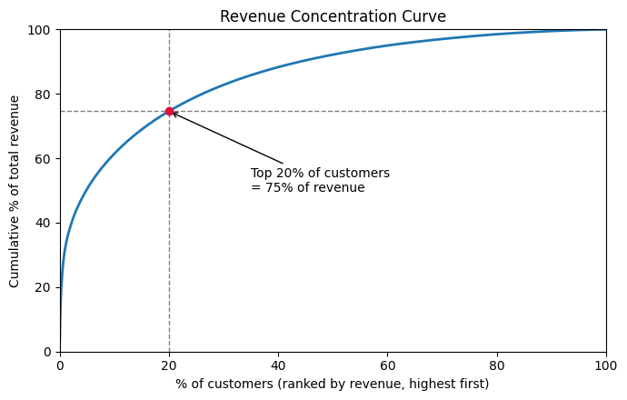

```python
cust_rev = clean.dropna(subset=['CustomerID']).groupby('CustomerID')['TotalPrice'].sum().sort_values(ascending=False)
cum_share = cust_rev.cumsum() / cust_rev.sum()
cust_share = np.arange(1, len(cust_rev)+1) / len(cust_rev)

top20_idx = int(np.ceil(len(cust_rev) * 0.20)) - 1
top20_share = cum_share.iloc[top20_idx]

fig, ax = plt.subplots(figsize=(7,4.5))
ax.plot(cust_share*100, cum_share*100, color='#1f77b4', lw=2)
ax.axvline(20, color='gray', ls='--', lw=1)
ax.axhline(top20_share*100, color='gray', ls='--', lw=1)
ax.scatter([20], [top20_share*100], color='crimson', zorder=5)
ax.annotate(f'Top 20% of customers\n= {top20_share*100:.0f}% of revenue',
            xy=(20, top20_share*100), xytext=(35, top20_share*100-25),
            arrowprops=dict(arrowstyle='->'))
ax.set_xlabel('% of customers (ranked by revenue, highest first)')
ax.set_ylabel('Cumulative % of total revenue')
ax.set_title('Revenue Concentration Curve')
ax.set_xlim(0,100); ax.set_ylim(0,100)
plt.tight_layout(); plt.show()
```

### 4.2 Customer Segmentation via RFM (Recency, Frequency, Monetary)

Why this matters: Knowing that revenue is concentrated helps you understand that most of your revenue comes from a few big customers. But, it doesn't identify which of those big customers are becoming less and less loyal or are losing interest in your business altogether. Your customers may be categorized based on Recency (how recently they bought a product), Frequency (how often they bought products), and Monetary (how much they spent). RFM analysis helps identify different purchasing behaviours and customer value profiles (Ho et al., 2023; Arefin et al., 2024).

The customers were rated separately for Recency, Frequency, and Monetary value. Their scores from these categories were aggregated and customers were then grouped into Champions Loyal At Risk (high-value customer), and Hibernating/Low value categories. The At Risk group represents an important segment. These 305 customers had historically spent well but had not ordered recently. This segment represents a potential retention risk because these customers have historically generated relatively high value but have not purchased recently (Han and Kwak, 2023). Without further investigation or targeted retention activity, some of this customer value may be lost. Champions, on the other hand, are already buying regularly and do not need aggressive outreach. They need loyalty perks.

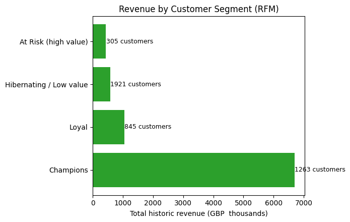

| Segment | Customers | Revenue |
| --- | --- | --- |
| Champions | 1263 | 6689610.79 |
| Loyal | 845 | 1041391.09 |
| Hibernating / Low value | 1921 | 573811.99 |
| At Risk (high value) | 305 | 432413.77 |

```python
snapshot = clean['InvoiceDate'].max() + pd.Timedelta(days=1)
rfm = clean.dropna(subset=['CustomerID']).groupby('CustomerID').agg(
    Recency=('InvoiceDate', lambda x: (snapshot - x.max()).days),
    Frequency=('InvoiceNo', 'nunique'),
    Monetary=('TotalPrice', 'sum'))

r_score = pd.qcut(rfm['Recency'], 4, labels=[4,3,2,1]).astype(int)
f_score = pd.qcut(rfm['Frequency'].rank(method='first'), 4, labels=[1,2,3,4]).astype(int)
m_score = pd.qcut(rfm['Monetary'], 4, labels=[1,2,3,4]).astype(int)
rfm['RFM_Score'] = r_score + f_score + m_score

def segment(row):
    if row['RFM_Score'] >= 10: return 'Champions'
    if row['RFM_Score'] >= 8: return 'Loyal'
    if r_score[row.name] <= 2 and m_score[row.name] >= 3: return 'At Risk (high value)'
    return 'Hibernating / Low value'

rfm['Segment'] = rfm.apply(segment, axis=1)
seg_summary = rfm.groupby('Segment').agg(Customers=('Recency','size'), Revenue=('Monetary','sum')).sort_values('Revenue', ascending=False)

fig, ax = plt.subplots(figsize=(7,4.5))
bars = ax.barh(seg_summary.index, seg_summary['Revenue']/1000, color='#2ca02c')
ax.set_xlabel('Total historic revenue (GBP  thousands)')
ax.set_title('Revenue by Customer Segment (RFM)')
for b, n in zip(bars, seg_summary['Customers']):
    ax.text(b.get_width()+5, b.get_y()+b.get_height()/2, f'{n} customers', va='center', fontsize=9)
plt.tight_layout(); plt.show()
seg_summary
```

What the analysis recommends: prioritise a win-back campaign for the 305 At Risk customers. A targeted retention intervention could therefore be considered, with the potential cost and expected return evaluated against the historical value of this customer segment.

### 4.3 Monthly Seasonality

Why this matters: Gift-ware demand can vary across the year, making the identification of temporal sales patterns relevant for planning and forecasting. However, the timing of peaks should be established from observed transaction data rather than assumed in advance (Kolassa, 2022). Accurate identification of the timing of increased demand can support more effective inventory and staffing planning and reduce the risk of under- or over-preparation. Revenue was aggregated by month and plotted against the annual average using a dashed reference line. For most of the year, monthly revenue sits in a fairly narrow band. A clear increase begins in September, followed by further growth in October and a peak in November. Revenue increased from September through October, with November representing the highest monthly revenue in the observed period. This pattern matches well with the idea of people needing their supplies more right before Christmas but of course the transaction data weren't totally sufficient to determine the real cause of the increase. Decline in December 2011 is very drastic, but it is a kind of a trick: only 9 December is contained in the dataset, the major part of the month is missing.

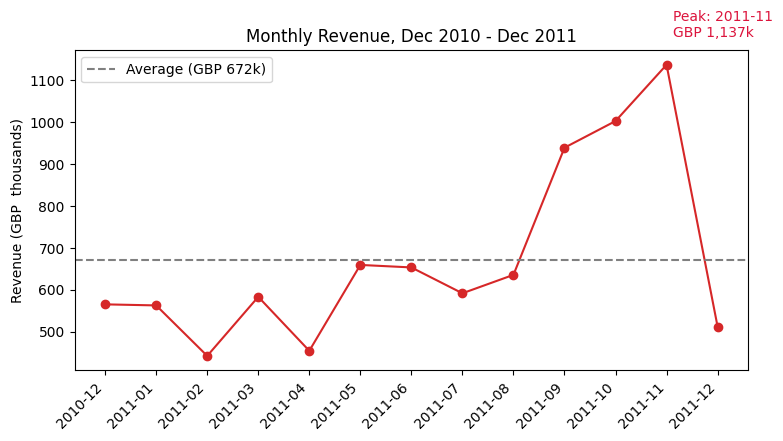

```python
monthly = clean.groupby('Month')['TotalPrice'].sum()
avg = monthly.mean()

fig, ax = plt.subplots(figsize=(8,4.5))
ax.plot(monthly.index, monthly.values/1000, marker='o', color='#d62728')
ax.axhline(avg/1000, color='gray', ls='--', label=f'Average (GBP {avg/1000:,.0f}k)')
peak = monthly.idxmax()
ax.annotate(f'Peak: {peak}\nGBP {monthly.max()/1000:,.0f}k', xy=(peak, monthly.max()/1000),
            xytext=(5, 20), textcoords='offset points', color='crimson')
ax.set_xticks(range(len(monthly.index)))
ax.set_xticklabels(monthly.index, rotation=45, ha='right')
ax.set_ylabel('Revenue (GBP  thousands)')
ax.set_title('Monthly Revenue, Dec 2010 - Dec 2011')
ax.legend()
plt.tight_layout(); plt.show()
```

What the analysis recommends: finalise supplier orders and warehouse staffing by August at the latest. By September the ramp is already underway, and scrambling at that point means lost sales.

### 4.4 When Do Customers Actually Order? (Day x Hour Heatmap)

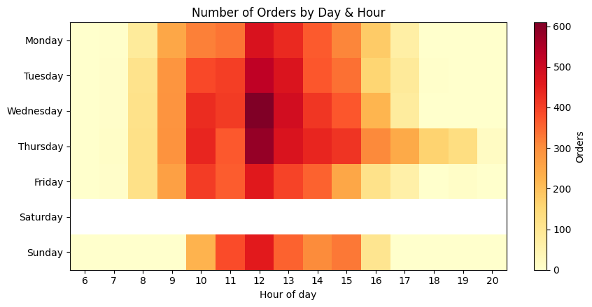

```python
order_counts = clean.drop_duplicates('InvoiceNo').groupby(['DayOfWeek','Hour']).size().unstack(fill_value=0)
day_order = ['Monday','Tuesday','Wednesday','Thursday','Friday','Saturday','Sunday']
order_counts = order_counts.reindex(day_order)

fig, ax = plt.subplots(figsize=(9,4.5))
im = ax.imshow(order_counts, aspect='auto', cmap='YlOrRd')
ax.set_yticks(range(len(order_counts.index))); ax.set_yticklabels(order_counts.index)
ax.set_xticks(range(len(order_counts.columns))); ax.set_xticklabels(order_counts.columns)
ax.set_xlabel('Hour of day'); ax.set_title('Number of Orders by Day & Hour')
plt.colorbar(im, ax=ax, label='Orders')
plt.tight_layout(); plt.show()
```

What the analysis recommends: concentrate marketing emails and support staffing during the highest-activity periods, maintain Sunday site availability, and investigate the absence of Saturday orders to determine whether this reflects deliberate business practice or a system issue.

### 4.5 Revenue Outside the UK - Where Is the Growth Opportunity?

Why this matters: The client is UK-registered, but orders come in from dozens of countries. Knowing which markets generate substantial purchasing activity, versus those producing relatively limited orders, can help inform decisions about customer behaviour and market-level commercial activity. Revenue was aggregated by country, with the UK separated from non-UK markets. The UK takes about 83 percent of total revenue. It is rather natural if the retailer happens to be UK-based. Even so, the second most fascinating fact is that the countries just below the UK are very important and among them, the major one is the Netherlands and Ireland. Germany, France and Australia also contribute their share, all of which are above the noise level (Eberhard, 2023). The combined revenue contribution from these five countries is not insignificant. In essence, there has already been sufficient demand, meaning these potential countries could be good targets for carrying out different local marketing tests.

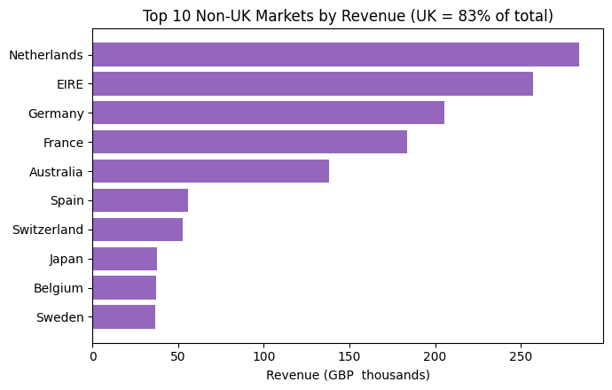

```python
country_rev = clean.groupby('Country')['TotalPrice'].sum().sort_values(ascending=False)
uk_share = country_rev['United Kingdom'] / country_rev.sum()
non_uk_top = country_rev.drop('United Kingdom').head(10)

fig, ax = plt.subplots(figsize=(7,4.5))
ax.barh(non_uk_top.index[::-1], non_uk_top.values[::-1]/1000, color='#9467bd')
ax.set_xlabel('Revenue (GBP  thousands)')
ax.set_title(f'Top 10 Non-UK Markets by Revenue (UK = {uk_share*100:.0f}% of total)')
plt.tight_layout(); plt.show()
```

What the analysis recommends: pilot localised marketing in the five identified markets before expanding expenditure to additional countries. The observed revenue demonstrates existing demand, while the effect of localisation should be evaluated through subsequent performance testing.

### 4.6 Where Are Returns/Cancellations Concentrated?

```
Note: a rate above 100% means cancelled value exceeded that country's gross sales in this period, i.e. a few large cancellations against a small sales base, not a data error.
```

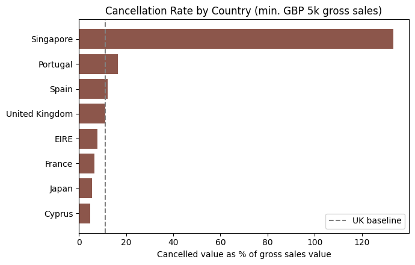

```python
cancelled['CancelValue'] = (cancelled['Quantity'] * cancelled['UnitPrice']).abs()
cancel_by_country = cancelled.groupby('Country')['CancelValue'].sum()
gross_by_country = clean.groupby('Country')['TotalPrice'].sum()

# only compare countries with a meaningful volume of gross sales
eligible = gross_by_country[gross_by_country > 5000]
cancellation_rate = (cancel_by_country / eligible).dropna().sort_values(ascending=False).head(8)
print('Note: a rate above 100% means cancelled value exceeded that country\'s gross sales in this period, i.e. a few large cancellations against a small sales base, not a data error.')

fig, ax = plt.subplots(figsize=(7,4.5))
bars = ax.barh(cancellation_rate.index[::-1], cancellation_rate.values[::-1]*100, color='#8c564b')
ax.axvline(cancellation_rate['United Kingdom']*100 if 'United Kingdom' in cancellation_rate.index else (cancel_by_country['United Kingdom']/gross_by_country['United Kingdom'])*100,
           color='gray', ls='--', label='UK baseline')
ax.set_xlabel('Cancelled value as % of gross sales value')
ax.set_title('Cancellation Rate by Country (min. GBP 5k gross sales)')
ax.legend()
plt.tight_layout(); plt.show()
```

What the analysis recommends: before increasing marketing expenditure in high-cancellation countries identified in Section 4.5, the fulfilment and transaction processes for those markets should first be investigated. Spending money to acquire customers who then cancel is worse than not acquiring them at all.

### 4.7 Which Products Are Bought Together? (Cross-Sell Opportunity)

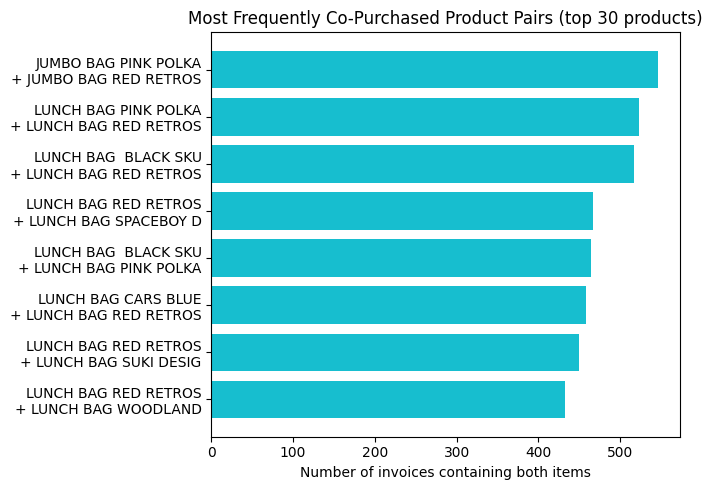

```python
top_products = clean['Description'].value_counts().head(30).index
baskets = clean[clean['Description'].isin(top_products)].groupby('InvoiceNo')['Description'].apply(set)

pair_counts = Counter()
for basket in baskets:
    for pair in combinations(sorted(basket), 2):
        pair_counts[pair] += 1

top_pairs = pd.Series(dict(pair_counts)).sort_values(ascending=False).head(8)
labels = [f'{a[:20]}\n+ {b[:20]}' for a, b in top_pairs.index]

fig, ax = plt.subplots(figsize=(7,5))
ax.barh(labels[::-1], top_pairs.values[::-1], color='#17becf')
ax.set_xlabel('Number of invoices containing both items')
ax.set_title('Most Frequently Co-Purchased Product Pairs (top 30 products)')
plt.tight_layout(); plt.show()
```

What the analysis recommends: create explicit bundle listings for these pairs on the website and in wholesale catalogues rather than relying on customers to find matching items independently.

## 5. Discussion and Conclusion

### 5.1 What Worked Well

All seven insights come from the same cleaned transaction dataset, and every cleaning step is documented and verified. This is a step towards reproducibility because the documented pipeline can be followed and verified using the same data and procedures. The insights themselves cover four business parts: who the customers are and how to retain them, when demand peaks, where international growth might come from, and what products to bundle. That breadth is intentional. A report that only answers one question, though well, is not that useful to a leadership team that has to take decisions across multiple functions.

### 5.2 What Could Be Better

Several limitations should be acknowledged. Dropping the rows without CustomerID meant losing about 25 percent of transactions from the customer-level analyses. The segmentation and Pareto findings are based only on transactions with identifiable CustomerIDs; therefore, the results may not fully represent customer activity associated with unidentified transactions. The dataset covers only one year, so the seasonality pattern is a single cycle. The seasonal pattern may recur in subsequent years; however, this cannot be established from a single year of transaction data. Cross-sell analysis was only for the top 30 products. So, a combination that might be great was left out, because of the low popularity of that product. As far as cancellation-rate numbers for low-volume countries are concerned, they are naturally quite variable, e. g. a cancellation of one large order can much alter the cancellation rate.

### 5.3 Recommendations

Pulling together the individual recommendations from each insight, the following priorities are proposed for the client:

1. Set up a key-account program for the top 20 percent of customers who drive about 75 percent of revenue.
2. Run a win-back campaign aimed at the 305 At Risk customers before their revenue disappears completely.
3. Get stock and staffing locked in by August to handle the September-November demand spike.
4. Time marketing emails for Tuesday to Thursday mornings, and investigate why Saturday has zero order activity.
5. Test localised marketing in the Netherlands, Ireland, Germany, France, and Australia before spreading budget more widely.
6. Check fulfilment processes in countries with high cancellation rates before spending marketing money there.
7. Bundle the product pairs that customers already buy together rather than guessing at combinations.

### 5.4 Final Thoughts

The project demonstrates that a single transactional dataset, when appropriately cleaned and visualised, can provide evidence for a wide range of business questions. None of the seven insights required machine learning or complex modelling. They were derived primarily through aggregation, counting and visualisation rather than complex predictive modelling. The value was not in the sophistication of the methods but in asking the right questions and presenting the answers in a way that connects to real decisions.

## References

Alotaibi, O., Pardede, E. and Tomy, S., 2023. Cleaning big data streams: a systematic literature review. Technologies, 11(4), p.101.

Anwar, D., Faizanuddin, M., Rahman, F. and Dayal, R., 2025. Analyzing consumer behavior in e-commerce: insights from data-driven approaches. Management (Montevideo), 3, pp.127-127.

Arefin, S., Parvez, R., Ahmed, T., Ahsan, M., Sumaiya, F., Jahin, F. and Hasan, M., 2024, May. Retail industry analytics: Unraveling consumer behavior through rfm segmentation and machine learning. In 2024 IEEE international conference on electro information technology (eIT) (pp. 545-551). IEEE.

Bousdekis, A., Lepenioti, K., Apostolou, D. and Mentzas, G., 2023. Data analytics in quality 4.0: literature review and future research directions. International Journal of Computer Integrated Manufacturing, 36(5), pp.678-701.

Dzuranin, A.C., 2022. Explanatory data visualizations. Strategic Finance, 103(7), pp.42-49.

Eberhard, K., 2023. The effects of visualization on judgment and decision-making: a systematic literature review. Management Review Quarterly, 73(1), pp.167-214.

Guo, M., Wang, Y., Yang, Q., Li, R., Zhao, Y., Li, C., Zhu, M., Cui, Y., Jiang, X., Sheng, S. and Li, Q., 2023. Normal workflow and key strategies for data cleaning toward real-world data. Interactive journal of medical research, 12(1), p.e44310.

Hadjimichael, A., Schlumberger, J. and Haasnoot, M., 2024. Data visualisation for decision making under deep uncertainty: current challenges and opportunities. Environmental Research Letters, 19(11), p.111011.

Han, S. and Kwak, I.Y., 2023. Mastering data visualization with Python: practical tips for researchers. Journal of Minimally Invasive Surgery, 26(4), p.167.

Ho, T., Nguyen, S., Nguyen, H., Nguyen, N., Man, D.S. and Le, T.G., 2023. An extended RFM model for customer behaviour and demographic analysis in retail industry. Business Systems Research: International journal of the Society for Advancing Innovation and Research in Economy, 14(1), pp.26-53.

John, J.M., Shobayo, O. and Ogunleye, B., 2023. An exploration of clustering algorithms for customer segmentation in the UK retail market. Analytics, 2(4), pp.809-823.

Kolassa, S., 2022. Commentary on the M5 forecasting competition. International journal of forecasting, 38(4), pp.1562-1568.

Mavrogiorgos, K., Kiourtis, A., Mavrogiorgou, A., Kleftakis, S. and Kyriazis, D., 2022, January. A multi-layer approach for data cleaning in the healthcare domain. In Proceedings of the 2022 8th international conference on computing and data engineering (pp. 22-28).

Ogrizović, M., Drašković, D. and Bojić, D., 2024. Quality assurance strategies for machine learning applications in big data analytics: an overview. Journal of Big Data, 11(1), p.156.

Sharifnia, A.M., Kpormegbey, D.E., Thapa, D.K. and Cleary, M., 2026. A primer of data cleaning in quantitative research: Handling missing values and outliers. Journal of advanced nursing, 82(1), pp.970-975.

Yin, S., Li, H., Sun, Y., Ibrar, M. and Teng, L., 2024. Data visualization analysis based on explainable artificial intelligence: A survey. IJLAI Transactions on Science and Engineering, 2(2), pp.13-20.